# Modèle “word2vec” pour la construction de vecteurs de mots

Author

Eléonore Khachaturova, Armand Garrigou, Léo Rongieras

# introduction

Ce document propose un résumé dans l’avancé de notre projet d’implémentation du modèle word2vec. On s’inspire directement des papiers originaux, voir Mikolov, Chen, et al. (2013) et Mikolov, Sutskever, et al. (2013) . Mikolov et son équipe propose deux architectures différentes pour obtenir une représentation vectorielle des mots : **CBOW** et **SKIP-GRAM**, nous proposerons ici d’implémenter le *continous bag of words* (CBOW). Nous donnons une explication de son fonctionnement en préambule de la mise en oeuvre du modèle, voir Section 1.1

Nous ferons l’implémentation python du modèle avec `pytorch` on utilisant notemment la classe de base`Module`[^1] pour construire notre modèle et la classe `Dataset`[^2] pout le pre-traitement et la préparation du corpus d’entrainement.

<sup>1</sup> voir [nn.Module](https://pytorch.org/docs/stable/generated/torch.nn.Module.html) pour la documentation officiel

<sup>2</sup> idem avec [Dataset](https://pytorch.org/tutorials/beginner/basics/data_tutorial.html)

## Continous bag of words

Le principal objectif de ce modèle est d’obtenir une répresentation de mot. Comme le nom “word2vec” l’indique, nous souhaitons obtenir finalement la représentation d’un mot sous forme d’un vecteur. Cette représentation numérique d’un mot est appellée *word embedding*. L’intuition qui est au départ de ce modèl est que le sens d’un mot est déterminé par son contexte, Saussure parlait de *l’entourage* d’un mot, c’est à dire les mots qui l’entourent dans la phrase. Ce qui est nommé contexte ici est représenté par les $N$ mots avant et les $N$ mots après le mot que nous souhaitons représenter. Soit la phrase :

> le chat dort les souris chantent

et $N=2$

le mot “dort” peut être représenté par : **[le, chat, les, souris]**

```
flowchart TB

  id1[le chat dort les souris chantent] -- w --> id[dort]

  id1[le chat dort les souris chantent] --w+1--> id4[les]
  id1[le chat dort les souris chantent] --w+2--> id5[souris]

  subgraph B[" "]
  id4[les]
  id5[souris]
  end

  subgraph Z[" "]
  direction LR
  id[dort]
  end
  id1[le chat dort les souris chantent] -- w-2 --> id2[le]
  id1[le chat dort les souris chantent] -- w-1 --> id3[chat]
  subgraph A[" "]
  id2[le]
  id3[chat]
  end
```

L’idée qu’un mot est déterminé par son contexte est parfaitement explicité dans les modèles de langue comme les modèles $n$-grams, on l’on assume que la probabilité de la présence d’un mot dans une phrase est déterminé par les mots qui précèdent, soit pour un modèle $bi$-gram :
$$P(w_1, w_2,...,w_n) = \prod_{i=2}^{n} P(w_i | w_{i-1})$$

Nous allons donc voir comment CBOW peut apprendre ces probabilités.

Notre modèle prend en entré un vecteur contexte $x$ et retourne un vecteur mot $y$ qui correspond au mot au centre de notre contexte. On définit deux matrices $\mathcal{W_1} \in \mathbb{R}^{|V| \times n} \text { et } \mathcal{W_2} \in \mathbb{R}^{n \times |V|}$ On note :

- $w_i$ le mot en position $i$ du vocabulaire $V$
- $\mathcal{W_1} \in \mathbb{R}^{|V| \times n}$ la matrice des mots en entré où $a_i$ correspond à la $i$-ème ligne de $\mathcal{W_1}$ c’est à dire le vecteur qui représente le mot en entré $w_i$
- $\mathcal{W_2} \in \mathbb{R}^{n \times |V|}$ la matrice en sortie où $y_i$ correspond à la $i$ème colone de $\mathcal{W_2}$ c’est à dire le vecteur qui représente le mot en sortie $w_i$
- $n$ correspond à la dimension arbitraire des embeddings

Les étapes du fonctionnement du modèle peuvent être décrites de telle sorte:

1. On crée un vecteur d’entré composé des indices $i$ des mots $\in V$ en contexte avec une fenètre de taille $N$ soit  
   $v^c = (x^{c-N},...,x^{c-1}, x^{c+1},...,x^{c+N})$
2. On obtient nos embeddings pour ce contexte. Soit $\mathcal{W_1}v^c$, on obtient une matrice de taille $N \times n$ ou chaque ligne $i$ correspond à l’embeddings du mot en contexte. Chaque vecteur dense est de dimension $n$
3. On veut récupérer la somme des vecteurs appartenant au contexte $C$, c’est à dire la somme des éléments **par colone** de notre matrices $\mathcal{W_1}v^c$ soit
   $$\widehat{x} = \sum_{i=1}^{N\times 2}a_i$$
4. Notre vecteur score $z$ est obtenu par
   $$z = \mathcal{W_2} \sum_{i=1}^{N\times 2}a_i = \mathcal{W_2}\widehat{x}$$
5. On retourne ce score transformé en log probabilité soit $\widehat{y} =$ log_softmax$(z)$

# Mise en oeuvre

<sup>3</sup> Le detail du corpus peut être trouvé [ici](https://huggingface.co/datasets/wikitext)

## Preprocessing

Nous procédons de telle manière :

- Récupération des donnés brutes
- On tokénise par **phrase**
- Puis on tokénise par **mot**
- On ajoute pour chaque phrase un token de début `bg` et un token de fin `end` un nombre de fois correspondant à la taille de notre fenètre.

A cet étape, avec une fenètre de taille $n = 2$ nous avons un corpus de la forme : `[[<bg>, <bg>,'une', 'première', 'phrase', <end>, <end>], [<bg>, <bg>,'une', 'deuxième', 'phrase', <end>, <end>], [...]]`

Nous ferons la démonstration ici avec un petit corpus pour rendre compte du fonctionnement de l’ensemble de notre code[^4]. On récupère les premières lignes du texte Au Bonheur Des Dames de Zola :

<sup>4</sup> L’ensemble du code peut être retrouvé sur le github du [projet](https://github.com/Lels07/word2vec-project-M1)

```python
text = """Denise était venue à pied de la gare Saint-Lazare, où un train de
Cherbourg l'avait débarquée avec ses deux frères, après une nuit
passée sur la dure banquette d'un wagon de troisième classe. Elle
tenait par la main Pépé, et Jean la suivait, tous les trois brisés
du voyage, effarés et perdus, au milieu du vaste Paris, le nez
levé sur les maisons, demandant à chaque carrefour la rue de la
Michodière, dans laquelle leur oncle Baudu demeurait. Mais, comme
elle débouchait enfin sur la place Gaillon, la jeune fille
s'arrêta net de surprise."""
```

Notre classe de Preprocessing est donnée en suivant ainsi que notre fichier de configuration dans lequel sont instanciés toutes nos constantes et hyperparamètres :

```python
import torch, string
from nltk.stem.wordnet import WordNetLemmatizer
from torch._C import dtype
from torch.utils.data import Dataset
from nltk.tokenize import word_tokenize
from nltk.tokenize import sent_tokenize
import nltk


class Preprocess(Dataset):

    def __init__(self, raw_data, window_size, fraction_size):

        vocab, word_to_idx, idx_to_word, exemples_data, training_exemples, training_data_raw = self.tokenize(raw_data, window_size, fraction_size)

        self.training_exemples = training_exemples
        self.vocab = vocab
        self.word_to_idx = word_to_idx
        self.idx_to_word = idx_to_word
        self.window_size = window_size
        self.exemples_data = exemples_data
        self.training_data_raw = training_data_raw

        # self.data = torch.tensor(training_exemples, dtype=torch.long)
        self.data_x = torch.tensor([ex[0] for ex in training_exemples], dtype=torch.long)
        self.data_y = torch.tensor([ex[1] for ex in training_exemples], dtype=torch.long)
        # self.data = training_exemples


    def __len__(self):

        return len(self.data_x)


    def __getitem__(self, index):
        x = self.data_x[index]
        y = self.data_y[index]

        return x, y

    def get_training_data(self, list_token, word_to_idx, window_size):

        data = []
        data_raw = []
        for ex in list_token:
            for i in range(len(ex) - window_size*2):
                window = ex[i: i + window_size*2+1]
                target = window.pop(window_size)
                context = window
                data.append(([word_to_idx[c] for c in context], word_to_idx[target]))
                data_raw.append((context, target))

        return data, data_raw


    def tokenize(self, corpus, window_size, fraction_size):

        """
        prend en entré le corpus brut
        et renvoie une liste de token après nettoyage des données

        """
        if corpus == 'toy_corpus':
            corpus = TOY
            sentences_list = sent_tokenize(corpus)


        elif corpus == 'gensim':
            import gensim.downloader as api
            dataset = api.load("20-newsgroups")
            data = [d for d in dataset][:int(fraction_size*len([d_ for d_ in dataset]))]
            print(f'fraction of data taken: {fraction_size}/1')

            sentences_list = []
            print("forming sentences..")
            for s in data:
                sentences_list.append(" ".join(s))
        else:
            sentences_list = sent_tokenize(corpus)[:int(fraction_size*len(sent_tokenize(corpus)))]


        print("tokenize the data...")


        punctation = string.punctuation + "``"

        list_token = []
        vocab = set()
        for s in sentences_list:

            token_words_s = word_tokenize(s)
            for i in range(window_size):
                token_words_s.append("<end>")
                token_words_s.insert(0, "<bg>")

            tok = []

            for w in token_words_s:
                if w not in punctation and not w.isdigit():
                    tok.append(w.lower())
                    vocab.add(w.lower())

            list_token.append(tok)


        list_token, vocab, word_to_idx, idx_to_word = self.get_data(list_token, vocab)

        training_data, training_data_raw = self.get_training_data(list_token, word_to_idx, window_size)

        return vocab, word_to_idx, idx_to_word, list_token, training_data, training_data_raw

    def get_data(self, list_token, vocab):

        '''
        prend en entré le corpus tokénisé et la window

        returns:
         - le vocabulaire : {word: count}
         - word_to_idx : {word: index}
         - idx_to_word : list[word]
        '''

        word_to_idx = {word: i for i, word in enumerate(vocab)}
        idx_to_word = list(word_to_idx.keys())

        return list_token, vocab, word_to_idx, idx_to_word
```

```python
import os
import torch

#############################
# Config all parameters here
#############################

DEVICE = torch.device("cuda") if torch.cuda.is_available() else torch.device("cpu")
RAW_DATA = 'gensim'
MODEL_ID = RAW_DATA
WINDOW_SIZE = 2
DISPLAY_LOSS = True


if RAW_DATA == 'gensim':

    #general parameters
    DISPLAY_N_BATCH = 2000
    SAVE_N_EPOCH = 1
    BATCH_SIZE = 16
    N_SAVE = 1
    EPOCH = 500

    #preprocess parameters
    WINDOW_SIZE = 2
    FRACTION_SIZE = 1

    # Model parameters
    EMBEDDING_DIM = 10
    LEARNING_RATE = 0.001

    #eval settings
    TEST_WORDS = ["elle", "jeune", "sur", "la"]

if RAW_DATA == 'toy_corpus':

    #toy corpus
    TOY = "word1 word2 word3 word4. word5 word6 word7 word8 word9. word10 word12 word13 word14. word15 word16 word17 word18"
    #general parameters
    DISPLAY_N_BATCH = 3000
    SAVE_N_EPOCH = 100
    BATCH_SIZE = 16
    N_SAVE = 50
    EPOCH = 300

    #preprocess parameters
    WINDOW_SIZE = 2
    FRACTION_SIZE = 1

    # Model parameters
    EMBEDDING_DIM = 5
    LEARNING_RATE = 0.001

    # eval settings
    TEST_WORDS = ["word2", "word4", "word12"]


##### Main trainer and utils settings

PREPROCESS_DATA_DIR = os.path.join(MODEL_ID, 'preprocessed')
PREPROCESS_DATA_PATH = os.path.join(PREPROCESS_DATA_DIR, 'preprocessed_' + MODEL_ID + "_" + str(FRACTION_SIZE) + '.pickle')
MODEL_DIR = os.path.join(MODEL_ID, "cbow")
```

Voici à quoi ressemble notre corpus après processing:

```python
test = Preprocess(text, WINDOW_SIZE, FRACTION_SIZE)
print(test.exemples_data)
```

```
tokenize the data...
[['<bg>', '<bg>', 'denise', 'était', 'venue', 'à', 'pied', 'de', 'la', 'gare', 'saint-lazare', 'où', 'un', 'train', 'de', 'cherbourg', "l'avait", 'débarquée', 'avec', 'ses', 'deux', 'frères', 'après', 'une', 'nuit', 'passée', 'sur', 'la', 'dure', 'banquette', "d'un", 'wagon', 'de', 'troisième', 'cla…
```

Depuis notre classe, on peut récupérer notre vocabulaire `vocab`, le dictionnaire qui map les mots à leurs indices `word_to_idx`, et la liste qui contient les mots selon leurs indices `idx_to_word`

```python
print(test.vocab)
print(test.word_to_idx)
print(test.idx_to_word)

print('la taille du vocabulaire est de: ', len(test.vocab))
```

```
{'nuit', 'nez', 'place', 'tenait', 'demeurait', 'leur', 'sur', 'enfin', 'effarés', 'ses', 'de', 'gare', 'net', 'carrefour', "s'arrêta", 'où', 'dure', 'les', 'banquette', 'denise', "d'un", 'surprise', 'après', 'voyage', 'fille', 'du', 'train', '<end>', 'wagon', 'au', 'laquelle', 'frères', 'une', 'pép…
{'nuit': 0, 'nez': 1, 'place': 2, 'tenait': 3, 'demeurait': 4, 'leur': 5, 'sur': 6, 'enfin': 7, 'effarés': 8, 'ses': 9, 'de': 10, 'gare': 11, 'net': 12, 'carrefour': 13, "s'arrêta": 14, 'où': 15, 'dure': 16, 'les': 17, 'banquette': 18, 'denise': 19, "d'un": 20, 'surprise': 21, 'après': 22, 'voyage':…
['nuit', 'nez', 'place', 'tenait', 'demeurait', 'leur', 'sur', 'enfin', 'effarés', 'ses', 'de', 'gare', 'net', 'carrefour', "s'arrêta", 'où', 'dure', 'les', 'banquette', 'denise', "d'un", 'surprise', 'après', 'voyage', 'fille', 'du', 'train', '<end>', 'wagon', 'au', 'laquelle', 'frères', 'une', 'pép…
la taille du vocabulaire est de:  78
```

Nous avons dit que nous passions en entré de notre modèle un vecteur contexte dont les éléments sont les indices des mots en contexte, de plus, la méthode `nn.Embeddings` de pytorch attend en entré un tensor. Nous proposons de préparer directement ces données d’entrainement sous la bonne forme, prêt à être traiter par notre modèle. Nous récupérons donc des exemples de la forme d’un tuple, toujours avec une fenêtre $n=2$ `[([indice1, indice2, indice3, indice4], target1)]`

```python
print(test.training_data_raw)
print(test.training_exemples)
print("le nombre de couple est de: ", len(test.training_exemples))
```

```
[(['<bg>', '<bg>', 'était', 'venue'], 'denise'), (['<bg>', 'denise', 'venue', 'à'], 'était'), (['denise', 'était', 'à', 'pied'], 'venue'), (['était', 'venue', 'pied', 'de'], 'à'), (['venue', 'à', 'de', 'la'], 'pied'), (['à', 'pied', 'la', 'gare'], 'de'), (['pied', 'de', 'gare', 'saint-lazare'], 'la'…
[([60, 60, 63, 57], 19), ([60, 19, 57, 56], 63), ([19, 63, 56, 64], 57), ([63, 57, 64, 10], 56), ([57, 56, 10, 53], 64), ([56, 64, 53, 11], 10), ([64, 10, 11, 55], 53), ([10, 53, 55, 15], 11), ([53, 11, 15, 68], 55), ([11, 55, 68, 26], 15), ([55, 15, 26, 10], 68), ([15, 68, 10, 54], 26), ([68, 26, 5…
le nombre de couple est de:  94
```

ce que nous passons en entré est un tensor des vecteurs contextes que nous avons constitués :

```python
print(test.data_x.size())
```

```
torch.Size([94, 4])
```

Cela correspond à une matrice de dimension $94 \times 4$, chaque ligne $i$ correspond au $i$-ème vecteur contexte

```python
print(test.data_y.size())
```

```
torch.Size([94])
```

correspond à un vecteurs colone, chaque ligne $i$ correspond à l’indice du $i$-ème mot target.

Nos données sont prête à être traiter par notre modèle.

## Construction du modèle

```python
import torch
import torch.nn as nn
import torch.nn.functional as F

class CBOWModeler(nn.Module):

  def __init__(self, vocab_size, embedding_dim):
    super(CBOWModeler, self).__init__()
    self.embeddings = nn.Embedding(vocab_size, embedding_dim)
    self.linear1 = nn.Linear(embedding_dim, vocab_size)

    initrange = 0.5 / embedding_dim
    self.embeddings.weight.data.uniform_(-initrange, initrange)

  def forward(self, input):
    '''
    calcul de la somme des contextes à laquelle on applique la transformation linéaire (tensor : [1, len(vocab)])

    returns: log_softmax appliqué à la transformation

    '''
    embedding = self.embeddings(input)
    embedding = torch.sum(embedding, dim=1)

    Z_1 = self.linear1(embedding)
    out = F.log_softmax(Z_1, dim=1)

    return out
```

```python
vocab = test.vocab
word_to_idx = test.word_to_idx
idx_to_word = test.idx_to_word
train_data = torch.utils.data.DataLoader(test, batch_size = BATCH_SIZE, shuffle = True)
```

```python
import torch.nn as nn
import numpy as np
from numpy.linalg import norm

def nearest_neighbour(X, embeddings, k):
    distance = nn.CosineSimilarity()
    dist = distance(X, embeddings)
    all_idx = np.argsort(-dist)[:k]
    all_cos = dist[all_idx]

    return all_idx, all_cos

def k_n_nn(model, words, word_to_idx, idx_to_word, k):
    model.eval()
    matrix = model.embeddings.weight.data.cpu()

    print(f"process to determine the {k} nearest words of {words}")

    for word in words:
        input = matrix[word_to_idx[word]]

        ranking, _ = nearest_neighbour(input, matrix, k=k+1)

        print(word.ljust(10), ' | ', ', '.join([idx_to_word[i] for i in ranking[1:]]))

    return {}
```

```python
import torch.optim as optim

loss_function = nn.NLLLoss()

total_loss = []

cbow = CBOWModeler(len(vocab), EMBEDDING_DIM).to(DEVICE)

grad = optim.Adam(cbow.parameters(), lr=LEARNING_RATE)

for epoch in range(EPOCH):

    # print(i)
    for batch_idx, (context, target) in enumerate(train_data):

        cbow.train()

        grad.zero_grad()
        context = context.to(DEVICE)
        target = target.to(DEVICE)

        y_pred = cbow(context)
        loss = loss_function(y_pred, target)

        loss.backward()
        grad.step()

        total_loss.append(loss.item())

print(total_loss)
```

```
[4.39211368560791, 4.3416218757629395, 4.351800441741943, 4.325103282928467, 4.394707202911377, 4.282807350158691, 4.414342403411865, 4.272019863128662, 4.332773208618164, 4.275679588317871, 4.33330774307251, 4.408328533172607, 4.297717094421387, 4.3700690269470215, 4.368196964263916, 4.271646499633…
```

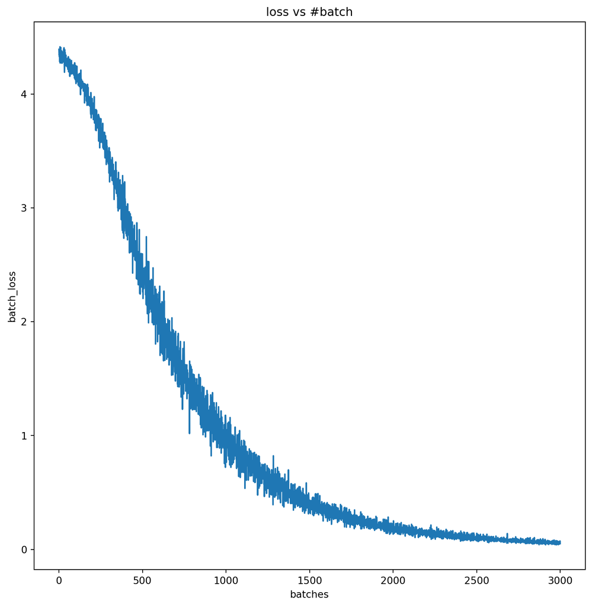

```python
import matplotlib
import matplotlib.pyplot as plt

plt.figure(figsize = (10, 10))
plt.xlabel("batches")
plt.ylabel("batch_loss")
plt.title("loss vs #batch")

plt.plot(total_loss)
plt.show()
```

```python
def predict(context):

  cont = [word_to_idx[word] for word in context]
  tensor = torch.tensor([cont])
  pred = cbow(tensor)

  return idx_to_word[torch.argmax(pred)]

correct = 0
for context, target in test.training_data_raw :
  if target == predict(context):
    correct += 1
print(correct/len(test.training_exemples))

test_words = ["tenait", "par", "main", "pépé"]
print(predict(test_words))
```

```
1.0
la
```

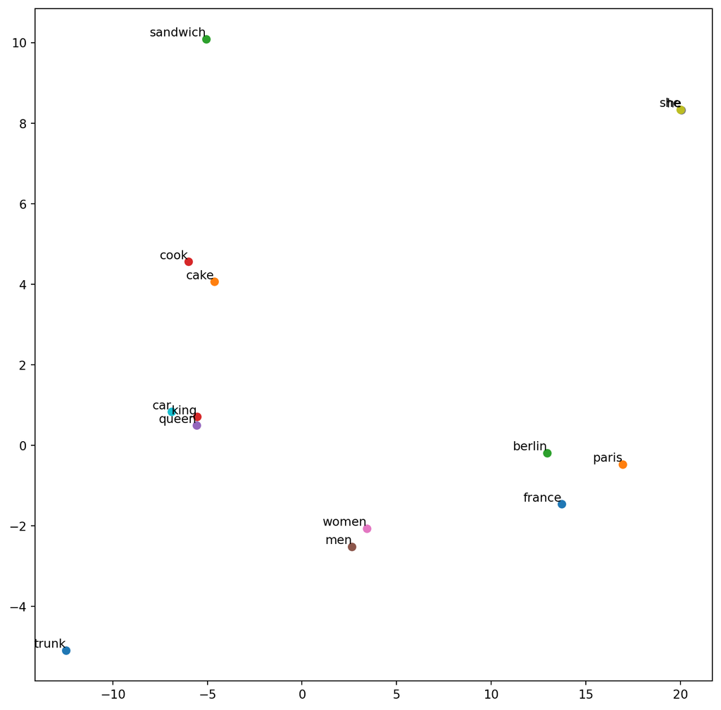

```python
from cbow import CBOWModeler
from sklearn.manifold import TSNE

mod = torch.load("./model499.pth", map_location=torch.device('cpu'))

idx_to_word = mod["idx_to_word"]
word_to_idx = mod["word_to_idx"]
total_loss = mod["total_loss"]

model = CBOWModeler(len(idx_to_word), 100)
model.load_state_dict(mod["cbow_state_dict"])

embeds = model.embeddings.weight.data.cpu()

tsne = TSNE(n_components = 2).fit_transform(embeds.cpu())
test_words = ['france', 'paris', 'berlin', 'king', 'queen', 'men', 'women', 'he', "she", "car", "trunk", "cake", "sandwich", "cook", ]
x, y = [], []
annotations = []
for idx, coord in enumerate(tsne):
    # print(coord)
    annotations.append(idx_to_word[idx])
    x.append(coord[0])
    y.append(coord[1])

plt.figure(figsize = (10, 10))
for i in range(len(test_words)):
    word = test_words[i]
    #print('word: ', word)
    vocab_idx = word_to_idx[word]
    # print('vocab_idx: ', vocab_idx)
    plt.scatter(x[vocab_idx], y[vocab_idx])
    plt.annotate(word, xy = (x[vocab_idx], y[vocab_idx]), \
        ha='right',va='bottom')

plt.savefig("w2v.png")
plt.show()
```

```

## References

Mikolov, Tomas, Kai Chen, Greg Corrado, and Jeffrey Dean. 2013. “Efficient Estimation of Word Representations in Vector Space.” https://arxiv.org/abs/1301.3781.

Mikolov, Tomas, Ilya Sutskever, Kai Chen, Greg Corrado, and Jeffrey Dean. 2013. “Distributed Representations of Words and Phrases and Their Compositionality.” https://arxiv.org/abs/1310.4546.